# EasyVisa_Full_Code_Notebook

#### Let's check the confusion matrix for all the models on validation set

##### Decision Tree Classifier

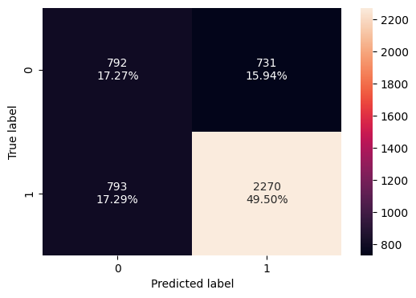

```python
confusion_matrix_sklearn(dtree_original,X_val,y_val)
```

##### Bagging Classifier

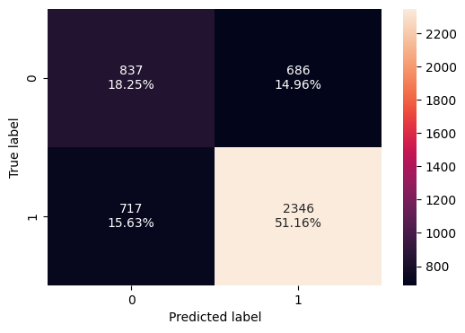

```python
confusion_matrix_sklearn(bagging_original,X_val,y_val)
```

##### Random Forest Classifier

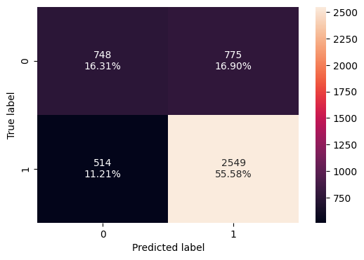

```python
confusion_matrix_sklearn(randomf_original,X_val,y_val)
```

##### Boosting Classifier

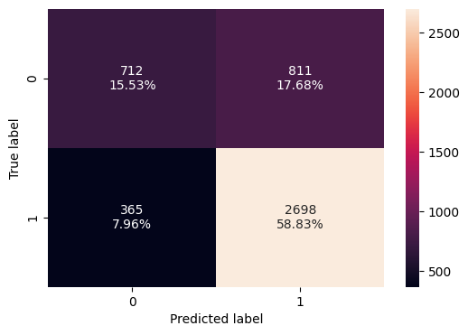

```python
confusion_matrix_sklearn(gradient_original,X_val,y_val)
```

##### Adaboost Classifier

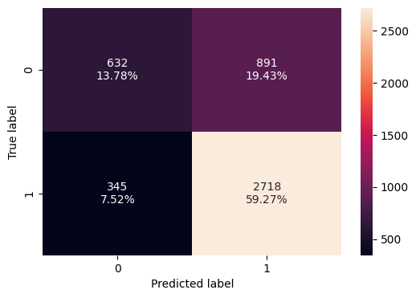

```python
confusion_matrix_sklearn(adaboost_original,X_val,y_val)
```

##### XGB Classifier

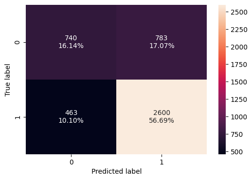

```python
confusion_matrix_sklearn(xgbboost_original,X_val,y_val)
```

### Observations on training and validation set performance for the Precision Metric for the original data

```python
scores_training_original_df.sort_values(by="Precision", ascending=False)
```

|  | model | Accuracy | Recall | Precision | F1 |
| --- | --- | --- | --- | --- | --- |
| 0 | Decision Tree - Training | 1.000000 | 1.000000 | 1.000000 | 1.000000 |
| 2 | Random Forest Classifier - Training | 0.999944 | 0.999916 | 1.000000 | 0.999958 |
| 1 | Bagging Classifier - Training | 0.985198 | 0.985982 | 0.991810 | 0.988887 |
| 5 | XGB Classifier - Training | 0.850807 | 0.935952 | 0.854537 | 0.893394 |
| 3 | Boosting Classifier - Training | 0.758802 | 0.883740 | 0.783042 | 0.830349 |
| 4 | AdaBoost Classifier - Training | 0.738226 | 0.887182 | 0.760688 | 0.819080 |

```python
scores_validation_original_df.sort_values(by="Precision", ascending=False)
```

|  | model | Accuracy | Recall | Precision | F1 |
| --- | --- | --- | --- | --- | --- |
| 1 | Bagging Classifier - Validation | 0.694069 | 0.765916 | 0.773747 | 0.769811 |
| 3 | Boosting Classifier - Validation | 0.743567 | 0.880836 | 0.768880 | 0.821059 |
| 5 | XGB Classifier - Validation | 0.728304 | 0.848841 | 0.768549 | 0.806702 |
| 2 | Random Forest Classifier - Validation | 0.718927 | 0.832191 | 0.766847 | 0.798184 |
| 0 | Decision Tree - Validation | 0.667684 | 0.741103 | 0.756415 | 0.748681 |
| 4 | AdaBoost Classifier - Validation | 0.730484 | 0.887365 | 0.753117 | 0.814748 |

### Model Building with Oversampled data

```python
# Fit SMOTE on train data(Synthetic Minority Oversampling Technique)
sm = SMOTE(random_state=1, sampling_strategy = 1,k_neighbors=5)
X_train_over, y_train_over = sm.fit_resample(X_train, y_train)
```

Let's see the counts before and after oversampling

```python
print("Before OverSampling, count of label '1': {}".format(sum(y_train == 1)))
print("Before OverSampling, count of label '0': {} \n".format(sum(y_train == 0)))

print("After OverSampling, count of label '1': {}".format(sum(y_train_over == 1)))
print("After OverSampling, count of label '0': {} \n".format(sum(y_train_over == 0)))

print("After OverSampling, the shape of train_X: {}".format(X_train_over.shape))
print("After OverSampling, the shape of train_y: {} \n".format(y_train_over.shape))
```

```
Before OverSampling, count of label '1': 11913
Before OverSampling, count of label '0': 5923

After OverSampling, count of label '1': 11913
After OverSampling, count of label '0': 11913

After OverSampling, the shape of train_X: (23826, 21)
After OverSampling, the shape of train_y: (23826,)
```

Create the dataframe to store the results on training and validation test

```python
results_df_over  = pd.DataFrame(columns=["model", "mean of cv_score training set","precision validation set"])
```

#### Decision Tree

```python
# Decision Tree Classifier
dtree_over=DecisionTreeClassifier(random_state=1)

# Fit the training set
dtree_over.fit(X_train_over,y_train_over)

# Get the cross validation scores
results = cross_val_score(dtree_over, X_train_over, y_train_over, cv=kfold, scoring=scorer_value)

# Get the precision for the validation data

precision=precision_score(y_val, dtree_over.predict(X_val))

# Add the mode, the cross validation mean precision and the precision on the validation set to a dataframe

results_df_over = results_df_over._append({"model": "OverSampled - Decision Classifier ", "mean of cv_score training set": results.mean(),"precision validation set": precision}, ignore_index=True)
```

#### Bagging Classifier

```python
#Bagging Classifier
bagging_over=BaggingClassifier(random_state=1)
#Fit the training set
bagging_over.fit(X_train_over,y_train_over)

# Get the cross validation scores
results = cross_val_score(bagging_over, X_train_over, y_train_over, cv=kfold, scoring=scorer_value)

# Get the precision for the validation data

precision=precision_score(y_val, bagging_over.predict(X_val))

# Add the mode, the cross validation mean precision and the precision on the validation set to a dataframe

results_df_over = results_df_over._append({"model": "OverSampled - Bagging Classifier ", "mean of cv_score training set": results.mean(),"precision validation set": precision}, ignore_index=True)
```

#### Random Forest Classifier

```python
#Random Forest Classifier

randomf_over=RandomForestClassifier(random_state=1)
# Fit the training set
randomf_over.fit(X_train_over,y_train_over)

# Get the cross validation scores
results = cross_val_score(randomf_over, X_train_over, y_train_over, cv=kfold, scoring=scorer_value)

# Get the precision for the validation data

precision=precision_score(y_val, randomf_over.predict(X_val))

# Add the mode, the cross validation mean precision and the precision on the validation set to a dataframe

results_df_over = results_df_over._append({"model": "OverSampled - Random Forest Classifier ", "mean of cv_score training set": results.mean(),"precision validation set": precision}, ignore_index=True)
```

#### Boosting Classifier

```python
#Gradient Boosting Classifier

gradient_over=GradientBoostingClassifier(random_state=1)

#Fit the training set

gradient_over.fit(X_train_over,y_train_over)

# Get the cross validation scores
results = cross_val_score(gradient_over, X_train_over, y_train_over, cv=kfold, scoring=scorer_value)

# Get the precision for the validation data

precision=precision_score(y_val, gradient_over.predict(X_val))

# Add the mode, the cross validation mean precision and the precision on the validation set to a dataframe

results_df_over = results_df_over._append({"model": "OverSampled - Gradient Boosting Classifier ", "mean of cv_score training set": results.mean(),"precision validation set": precision}, ignore_index=True)
```

#### Adaboost Classifier

```python
#Adaboost Classifier

adaboost_over=AdaBoostClassifier(random_state=1)

# Fit the training set

adaboost_over.fit(X_train_over,y_train_over)

# Get the cross validation scores
results = cross_val_score(adaboost_over, X_train_over, y_train_over, cv=kfold, scoring=scorer_value)

# Get the precision for the validation data

precision=precision_score(y_val, adaboost_over.predict(X_val))

# Add the mode, the cross validation mean precision and the precision on the validation set to a dataframe

results_df_over = results_df_over._append({"model": "OverSampled - AdaBoost Classifier ", "mean of cv_score training set": results.mean(),"precision validation set": precision}, ignore_index=True)
```

#### XGB Classifier

```python
#XGB Classifier
xgbboost_over=XGBClassifier(random_state=1, eval_metric="logloss")

#Fit the training set

xgbboost_over.fit(X_train_over,y_train_over)

# Get the cross validation scores
results = cross_val_score(xgbboost_over, X_train_over, y_train_over, cv=kfold, scoring=scorer_value)

# Get the precision for the validation data

precision=precision_score(y_val, xgbboost_over.predict(X_val))

# Add the mode, the cross validation mean precision and the precision on the validation set to a dataframe

results_df_over = results_df_over._append({"model": "OverSampled - XGB Classifier ", "mean of cv_score training set": results.mean(),"precision validation set": precision}, ignore_index=True)
```

#### Print the cross validation score and the precision score for the validaton set for all the models

```python
results_df_over
```

|  | model | mean of cv_score training set | precision validation set |
| --- | --- | --- | --- |
| 0 | OverSampled - Decision Classifier | 0.732429 | 0.755774 |
| 1 | OverSampled - Bagging Classifier | 0.777039 | 0.781410 |
| 2 | OverSampled - Random Forest Classifier | 0.777964 | 0.774204 |
| 3 | OverSampled - Gradient Boosting Classifier | 0.782888 | 0.781416 |
| 4 | OverSampled - AdaBoost Classifier | 0.761309 | 0.758252 |
| 5 | OverSampled - XGB Classifier | 0.774594 | 0.772433 |

- As we can see in the table above, the precision metric on the validation set has improve a little but they are all still under 80%.

#### Let's check the model performance for all metrics and all models in training and validation sets

##### Decision Tree

```python
scores_training_over_df = pd.DataFrame(columns=["model", "Accuracy","Recall","Precision","F1"])
scores_validation_over_df = pd.DataFrame(columns=["model", "Accuracy","Recall","Precision","F1"])
```

```python
# Decission Classifier Training Set
dtree_over_perfm_t=model_performance_classification_sklearn(dtree_over,X_train_over,y_train_over)
scores_training_over_df = add_scores(scores_training_over_df, dtree_over_perfm_t, "Oversampled Decision Tree - Training")

# Decision Classifier Validation Set
dtree_over_perfm_v=model_performance_classification_sklearn(dtree_over,X_val,y_val)
scores_validation_over_df = add_scores(scores_validation_over_df, dtree_over_perfm_v, "Oversampled Decision Tree - Validation")
```

##### Bagging Classifier

```python
# Bagging Classifier Training Set
bag_over_perfm_t=model_performance_classification_sklearn(bagging_over,X_train_over,y_train_over)
scores_training_over_df = add_scores(scores_training_over_df, bag_over_perfm_t, "Oversampled Bagging Classifier - Training")

# Bagging Classifier Validation Set
bag_over_perfm_v=model_performance_classification_sklearn(bagging_over,X_val,y_val)
scores_validation_over_df = add_scores(scores_validation_over_df, bag_over_perfm_v, "Oversampled Bagging Classifier - Validation")
```

##### Random Forest Classifier

```python
# Random Forest Classifier Training Set
rf_over_perfm_t=model_performance_classification_sklearn(randomf_over,X_train_over,y_train_over)
scores_training_over_df = add_scores(scores_training_over_df, rf_over_perfm_t, "Oversampled Random Forest Classifier - Training")

# Random ForestClassifier Validation Set
rf_over_perfm_v=model_performance_classification_sklearn(randomf_over,X_val,y_val)
scores_validation_over_df = add_scores(scores_validation_over_df, rf_over_perfm_v, "Oversampled Random Forest Classifier - Validation")
```

##### Boosting Classifier

```python
# Boosting Classifier Training Set
boo_over_perfm_t=model_performance_classification_sklearn(gradient_over,X_train_over,y_train_over)
scores_training_over_df = add_scores(scores_training_over_df, boo_over_perfm_t, "Oversampled Boosting Classifier - Training")

# Boosting Classifier Validation Set
boo_over_perfm_v=model_performance_classification_sklearn(gradient_over,X_val,y_val)
scores_validation_over_df = add_scores(scores_validation_over_df, boo_over_perfm_v, "Oversampled Boosting Classifier - Validation")
```

##### AdaBoost Classifier

```python
# Adaboost Classifier Training Set
ada_over_perfm_t=model_performance_classification_sklearn(adaboost_over,X_train_over,y_train_over)
scores_training_over_df = add_scores(scores_training_over_df, ada_over_perfm_t, "Oversampled AdaBoost Classifier - Training")

# Adaboost Classifier Validation Set
ada_over_perfm_v=model_performance_classification_sklearn(adaboost_over,X_val,y_val)
scores_validation_over_df = add_scores(scores_validation_over_df, ada_over_perfm_v, "Oversampled AdaBoost Classifier - Validation")
```

##### XGB Classifier

```python
# Boosting Classifier Training Set
xgb_over_perfm_t=model_performance_classification_sklearn(xgbboost_over,X_train_over,y_train_over)
scores_training_over_df = add_scores(scores_training_over_df, xgb_over_perfm_t, "Oversampled XGB Classifier - Training")

# Boosting Classifier Validation Set
xgb_over_perfm_v=model_performance_classification_sklearn(xgbboost_over,X_val,y_val)
scores_validation_over_df = add_scores(scores_validation_over_df, xgb_over_perfm_v, "Oversampled XGB Classifier - Validation")
```

##### Print Training Scores

```python
scores_training_over_df.sort_values(by="Precision", ascending=False)
```

|  | model | Accuracy | Recall | Precision | F1 |
| --- | --- | --- | --- | --- | --- |
| 0 | Oversampled Decision Tree - Training | 1.000000 | 1.000000 | 1.000000 | 1.000000 |
| 2 | Oversampled Random Forest Classifier - Training | 1.000000 | 1.000000 | 1.000000 | 1.000000 |
| 1 | Oversampled Bagging Classifier - Training | 0.985940 | 0.980442 | 0.991343 | 0.985862 |
| 5 | Oversampled XGB Classifier - Training | 0.875598 | 0.903719 | 0.855599 | 0.879001 |
| 3 | Oversampled Boosting Classifier - Training | 0.801687 | 0.825149 | 0.788165 | 0.806233 |
| 4 | Oversampled AdaBoost Classifier - Training | 0.779862 | 0.816083 | 0.760958 | 0.787557 |

- According to the precision scores for training, the top tree models for oversampled data are : 1) Oversampled Decision Tree (Precision 1) , 2) Oversampled Random Forest (Precision:1) and 3) Oversampled Bagging Classifier (Precision:0.0.991343)

##### Print Validation Scores

```python
scores_validation_over_df.sort_values(by="Precision", ascending=False)
```

|  | model | Accuracy | Recall | Precision | F1 |
| --- | --- | --- | --- | --- | --- |
| 3 | Oversampled Boosting Classifier - Validation | 0.725687 | 0.818152 | 0.781416 | 0.799362 |
| 1 | Oversampled Bagging Classifier - Validation | 0.692543 | 0.749265 | 0.781410 | 0.765000 |
| 2 | Oversampled Random Forest Classifier - Validation | 0.711295 | 0.801502 | 0.774204 | 0.787616 |
| 5 | Oversampled XGB Classifier - Validation | 0.717401 | 0.817826 | 0.772433 | 0.794481 |
| 4 | Oversampled AdaBoost Classifier - Validation | 0.700611 | 0.809990 | 0.758252 | 0.783268 |
| 0 | Oversampled Decision Tree - Validation | 0.660488 | 0.726412 | 0.755774 | 0.740802 |

- According to the precision scores for validation, the top tree models for oversampled data are : 1) Oversampled Boosting Classifier (Precision 0.781416) , 2) Oversampled Bagging Classifier (Precision:0.781410) and 3) Oversampled Random Forest Classifier (Precision:0.774204)
- The scores for the validation set are still between 70% and 80%.

#### Let's check the confusion matrix for all the models on validation set

##### Decision Tree Classifier

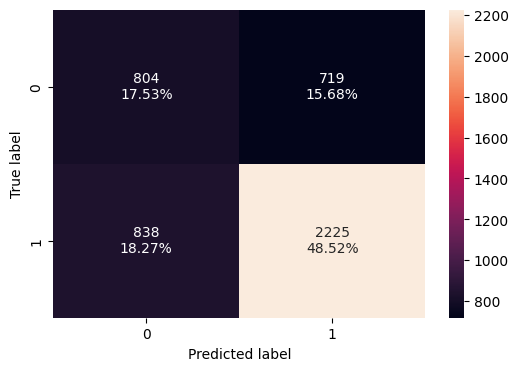

```python
confusion_matrix_sklearn(dtree_over,X_val,y_val)
```

##### Bagging Classifier

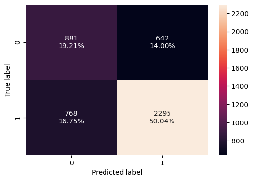

```python
confusion_matrix_sklearn(bagging_over,X_val,y_val)
```

##### Random Forest Classifier

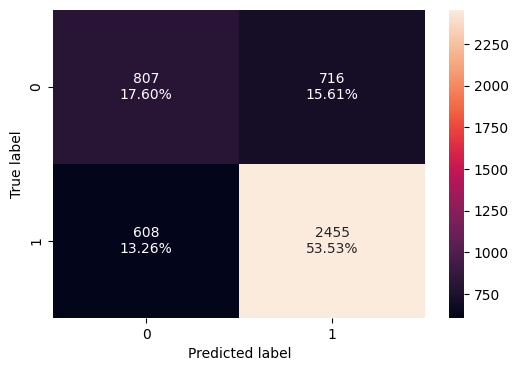

```python
confusion_matrix_sklearn(randomf_over,X_val,y_val)
```

##### Boosting Classifier

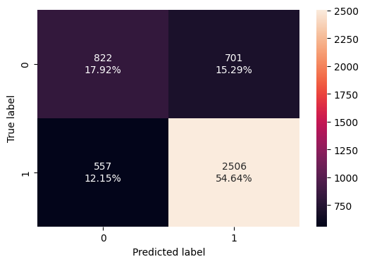

```python
confusion_matrix_sklearn(gradient_over,X_val,y_val)
```

##### Adaboost Classifier

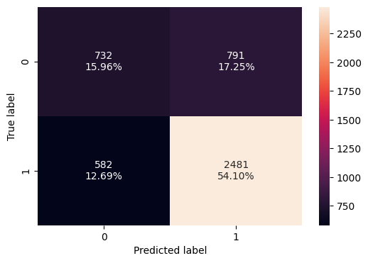

```python
confusion_matrix_sklearn(adaboost_over,X_val,y_val)
```

##### XGB Classifier

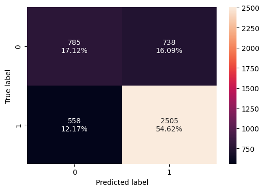

```python
confusion_matrix_sklearn(xgbboost_over,X_val,y_val)
```

### Observations on training and validation set performance for the Precision Metric for the oversampled data

- The performance for the validation set has increased slightly in the models with oversampled data vs the models with original data (1% or less) but in case of Precision is still under 80%.
- For the training set, the top tree models for oversampled data are : 1) Oversampled Decision Tree (Precision 1) , 2) Oversampled Random Forest (Precision:1) and 3) Oversampled Bagging Classifier (Precision:0.0.991343)
- For the validation set, , the top tree models for oversampled data are : 1) Oversampled Boosting Classifier (Precision 0.781416) , 2) Oversampled Bagging Classifier (Precision:0.781410) and 3) Oversampled Random Forest Classifier (Precision:0.774204)

```python
scores_training_over_df.sort_values(by="Precision", ascending=False)
```

|  | model | Accuracy | Recall | Precision | F1 |
| --- | --- | --- | --- | --- | --- |
| 0 | Oversampled Decision Tree - Training | 1.000000 | 1.000000 | 1.000000 | 1.000000 |
| 2 | Oversampled Random Forest Classifier - Training | 1.000000 | 1.000000 | 1.000000 | 1.000000 |
| 1 | Oversampled Bagging Classifier - Training | 0.985940 | 0.980442 | 0.991343 | 0.985862 |
| 5 | Oversampled XGB Classifier - Training | 0.875598 | 0.903719 | 0.855599 | 0.879001 |
| 3 | Oversampled Boosting Classifier - Training | 0.801687 | 0.825149 | 0.788165 | 0.806233 |
| 4 | Oversampled AdaBoost Classifier - Training | 0.779862 | 0.816083 | 0.760958 | 0.787557 |

```python
scores_validation_over_df.sort_values(by="Precision", ascending=False)
```

|  | model | Accuracy | Recall | Precision | F1 |
| --- | --- | --- | --- | --- | --- |
| 3 | Oversampled Boosting Classifier - Validation | 0.725687 | 0.818152 | 0.781416 | 0.799362 |
| 1 | Oversampled Bagging Classifier - Validation | 0.692543 | 0.749265 | 0.781410 | 0.765000 |
| 2 | Oversampled Random Forest Classifier - Validation | 0.711295 | 0.801502 | 0.774204 | 0.787616 |
| 5 | Oversampled XGB Classifier - Validation | 0.717401 | 0.817826 | 0.772433 | 0.794481 |
| 4 | Oversampled AdaBoost Classifier - Validation | 0.700611 | 0.809990 | 0.758252 | 0.783268 |
| 0 | Oversampled Decision Tree - Validation | 0.660488 | 0.726412 | 0.755774 | 0.740802 |

### Model Building with Undersampled data

```python
# fit random under sampler on the train data
rus = RandomUnderSampler(random_state=1, sampling_strategy =1)
X_train_un, y_train_un = rus.fit_resample(X_train, y_train)
```

```python
print("Before Under Sampling, count of label '1': {}".format(sum(y_train == 1)))
print("Before Under Sampling, count of label '0': {} \n".format(sum(y_train == 0)))

print("After Under Sampling, count of label '1': {}".format(sum(y_train_un == 1)))
print("After Under Sampling, count of label '0': {} \n".format(sum(y_train_un == 0)))

print("After Under Sampling, the shape of train_X: {}".format(X_train_un.shape))
print("After Under Sampling, the shape of train_y: {} \n".format(y_train_un.shape))
```

```
Before Under Sampling, count of label '1': 11913
Before Under Sampling, count of label '0': 5923

After Under Sampling, count of label '1': 5923
After Under Sampling, count of label '0': 5923

After Under Sampling, the shape of train_X: (11846, 21)
After Under Sampling, the shape of train_y: (11846,)
```

Create the dataframe to store the results on training and validation test

```python
results_df_under  = pd.DataFrame(columns=["model", "mean of cv_score training set","precision validation set"])
```

#### Decision Tree

```python
# Decision Tree Classifier
dtree_under=DecisionTreeClassifier(random_state=1)

# Fit the training set
dtree_under.fit(X_train_un,y_train_un)

# Get the cross validation scores
results = cross_val_score(dtree_under, X_train_un, y_train_un, cv=kfold, scoring=scorer_value)

# Get the precision for the validation data

precision=precision_score(y_val, dtree_under.predict(X_val))

# Add the mode, the cross validation mean precision and the precision on the validation set to a dataframe

results_df_under = results_df_under._append({"model": "Undersampled - Decision Classifier ", "mean of cv_score training set": results.mean(),"precision validation set": precision}, ignore_index=True)
```

#### Bagging Classifier

```python
#Bagging Classifier
bagging_under=BaggingClassifier(random_state=1)
#Fit the training set
bagging_under.fit(X_train_un,y_train_un)

# Get the cross validation scores
results = cross_val_score(bagging_under, X_train_un, y_train_un, cv=kfold, scoring=scorer_value)

# Get the precision for the validation data

precision=precision_score(y_val, bagging_under.predict(X_val))

# Add the mode, the cross validation mean precision and the precision on the validation set to a dataframe

results_df_under = results_df_under._append({"model": "Undersampled - Bagging Classifier ", "mean of cv_score training set": results.mean(),"precision validation set": precision}, ignore_index=True)
```

#### Random Forest Classifier

```python
#Random Forest Classifier

randomf_under=RandomForestClassifier(random_state=1)
# Fit the training set
randomf_under.fit(X_train_un,y_train_un)

# Get the cross validation scores
results = cross_val_score(randomf_under, X_train_un, y_train_un, cv=kfold, scoring=scorer_value)

# Get the precision for the validation data

precision=precision_score(y_val, randomf_under.predict(X_val))

# Add the mode, the cross validation mean precision and the precision on the validation set to a dataframe

results_df_under = results_df_under._append({"model": "UnderSampled - Random Forest Classifier ", "mean of cv_score training set": results.mean(),"precision validation set": precision}, ignore_index=True)
```

#### Boosting Classifier

```python
#Gradient Boosting Classifier

gradient_under=GradientBoostingClassifier(random_state=1)

#Fit the training set

gradient_under.fit(X_train_un,y_train_un)

# Get the cross validation scores
results = cross_val_score(gradient_under, X_train_un, y_train_un, cv=kfold, scoring=scorer_value)

# Get the precision for the validation data

precision=precision_score(y_val, gradient_under.predict(X_val))

# Add the mode, the cross validation mean precision and the precision on the validation set to a dataframe

results_df_under = results_df_under._append({"model": "UnderSampled - Gradient Boosting Classifier ", "mean of cv_score training set": results.mean(),"precision validation set": precision}, ignore_index=True)
```

#### Adaboost Classifier

```python
#Adaboost Classifier

adaboost_under=AdaBoostClassifier(random_state=1)

# Fit the training set

adaboost_under.fit(X_train_un,y_train_un)

# Get the cross validation scores
results = cross_val_score(adaboost_under, X_train_un, y_train_un, cv=kfold, scoring=scorer_value)

# Get the precision for the validation data

precision=precision_score(y_val, adaboost_under.predict(X_val))

# Add the mode, the cross validation mean precision and the precision on the validation set to a dataframe

results_df_under = results_df_under._append({"model": "UnderSampled - AdaBoost Classifier ", "mean of cv_score training set": results.mean(),"precision validation set": precision}, ignore_index=True)
```

#### XGB Classifier

```python
#XGB Classifier
xgbboost_under=XGBClassifier(random_state=1, eval_metric="logloss")

#Fit the training set

xgbboost_under.fit(X_train_un,y_train_un)

# Get the cross validation scores
results = cross_val_score(xgbboost_under, X_train_un, y_train_un, cv=kfold, scoring=scorer_value)

# Get the precision for the validation data

precision=precision_score(y_val, xgbboost_under.predict(X_val))

# Add the mode, the cross validation mean precision and the precision on the validation set to a dataframe

results_df_under = results_df_under._append({"model": "UnderSampled - XGB Classifier ", "mean of cv_score training set": results.mean(),"precision validation set": precision}, ignore_index=True)
```

#### Print the cross validation score and the precision score for the validaton set for all the models

```python
results_df_under
```

|  | model | mean of cv_score training set | precision validation set |
| --- | --- | --- | --- |
| 0 | Undersampled - Decision Classifier | 0.619404 | 0.762193 |
| 1 | Undersampled - Bagging Classifier | 0.687845 | 0.804075 |
| 2 | UnderSampled - Random Forest Classifier | 0.693364 | 0.808469 |
| 3 | UnderSampled - Gradient Boosting Classifier | 0.706372 | 0.819444 |
| 4 | UnderSampled - AdaBoost Classifier | 0.686315 | 0.805740 |
| 5 | UnderSampled - XGB Classifier | 0.691266 | 0.808997 |

- As we can see in the table above, the precision metric on the validation set has improve a little getting some models at 80% or even 81% precision in the validation set.

#### Let's check the model performance for all metrics and all models in training and validation sets

##### Decision Tree

```python
scores_training_under_df = pd.DataFrame(columns=["model", "Accuracy","Recall","Precision","F1"])
scores_validation_under_df = pd.DataFrame(columns=["model", "Accuracy","Recall","Precision","F1"])
```

```python
# Decission Classifier Training Set
dtree_under_perfm_t=model_performance_classification_sklearn(dtree_under,X_train_un,y_train_un)
scores_training_under_df = add_scores(scores_training_under_df, dtree_under_perfm_t, "Undersampled Decision Tree - Training")

# Decision Classifier Validation Set
dtree_under_perfm_v=model_performance_classification_sklearn(dtree_under,X_val,y_val)
scores_validation_under_df = add_scores(scores_validation_under_df, dtree_under_perfm_v, "Undersampled Decision Tree - Validation")
```

##### Bagging Classifier

```python
# Bagging Classifier Training Set
bag_under_perfm_t=model_performance_classification_sklearn(bagging_under,X_train_un,y_train_un)
scores_training_under_df = add_scores(scores_training_under_df, bag_under_perfm_t, "Undersampled Bagging Classifier - Training")

# Bagging Classifier Validation Set
bag_under_perfm_v=model_performance_classification_sklearn(bagging_under,X_val,y_val)
scores_validation_under_df = add_scores(scores_validation_under_df, bag_under_perfm_v, "Undersampled Bagging Classifier - Validation")
```

##### Random Forest Classifier

```python
# Random Forest Classifier Training Set
rf_under_perfm_t=model_performance_classification_sklearn(randomf_under,X_train_un,y_train_un)
scores_training_under_df = add_scores(scores_training_under_df, rf_under_perfm_t, "Undersampled Random Forest Classifier - Training")

# Random ForestClassifier Validation Set
rf_under_perfm_v=model_performance_classification_sklearn(randomf_under,X_val,y_val)
scores_validation_under_df = add_scores(scores_validation_under_df, rf_under_perfm_v, "Undersampled Random Forest Classifier - Validation")
```

##### Boosting Classifier

```python
# Boosting Classifier Training Set
boo_under_perfm_t=model_performance_classification_sklearn(gradient_under,X_train_un,y_train_un)
scores_training_under_df = add_scores(scores_training_under_df, boo_under_perfm_t, "Undersampled Boosting Classifier - Training")

# Boosting Classifier Validation Set
boo_under_perfm_v=model_performance_classification_sklearn(gradient_under,X_val,y_val)
scores_validation_under_df = add_scores(scores_validation_under_df, boo_under_perfm_v, "Undersampled Boosting Classifier - Validation")
```

##### AdaBoost Classifier

```python
# Adaboost Classifier Training Set
ada_under_perfm_t=model_performance_classification_sklearn(adaboost_under,X_train_un,y_train_un)
scores_training_under_df = add_scores(scores_training_under_df, ada_under_perfm_t, "Undersampled AdaBoost Classifier - Training")

# Adaboost Classifier Validation Set
ada_under_perfm_v=model_performance_classification_sklearn(adaboost_under,X_val,y_val)
scores_validation_under_df = add_scores(scores_validation_under_df, ada_under_perfm_v, "Undersampled AdaBoost Classifier - Validation")
```

##### XGB Classifier

```python
# Boosting Classifier Training Set
xgb_under_perfm_t=model_performance_classification_sklearn(xgbboost_under,X_train_un,y_train_un)
scores_training_under_df = add_scores(scores_training_under_df, xgb_under_perfm_t, "Undersampled XGB Classifier - Training")

# Boosting Classifier Training Set
xgb_under_perfm_v=model_performance_classification_sklearn(xgbboost_under,X_val,y_val)
scores_validation_under_df = add_scores(scores_validation_under_df, xgb_under_perfm_v, "Undersampled XGB Classifier - Validation")
```

##### Print Training Scores

```python
scores_training_under_df.sort_values(by="Precision", ascending=False)
```

|  | model | Accuracy | Recall | Precision | F1 |
| --- | --- | --- | --- | --- | --- |
| 0 | Undersampled Decision Tree - Training | 1.000000 | 1.000000 | 1.000000 | 1.000000 |
| 2 | Undersampled Random Forest Classifier - Training | 1.000000 | 1.000000 | 1.000000 | 1.000000 |
| 1 | Undersampled Bagging Classifier - Training | 0.980415 | 0.969272 | 0.991366 | 0.980195 |
| 5 | Undersampled XGB Classifier - Training | 0.855732 | 0.859699 | 0.852931 | 0.856302 |
| 3 | Undersampled Boosting Classifier - Training | 0.722860 | 0.729529 | 0.719927 | 0.724696 |
| 4 | Undersampled AdaBoost Classifier - Training | 0.700152 | 0.719061 | 0.692858 | 0.705717 |

- According to the precision scores for training, the top tree models for undersampled data are : 1)Undersampled Decision Tree (Precision 1) , 2) Undersampled Random Forest (Precision:1) and 3) Undersampled Bagging Classifier (Precision:0.991366)

##### Print Validation Scores

```python
scores_validation_under_df.sort_values(by="Precision", ascending=False)
```

|  | model | Accuracy | Recall | Precision | F1 |
| --- | --- | --- | --- | --- | --- |
| 3 | Undersampled Boosting Classifier - Validation | 0.703227 | 0.712700 | 0.819444 | 0.762354 |
| 5 | Undersampled XGB Classifier - Validation | 0.685565 | 0.692785 | 0.808997 | 0.746395 |
| 2 | Undersampled Random Forest Classifier - Valida... | 0.672045 | 0.666993 | 0.808469 | 0.730948 |
| 4 | Undersampled AdaBoost Classifier - Validation | 0.694505 | 0.714985 | 0.805740 | 0.757654 |
| 1 | Undersampled Bagging Classifier - Validation | 0.638029 | 0.605615 | 0.804075 | 0.690875 |
| 0 | Undersampled Decision Tree - Validation | 0.615787 | 0.617369 | 0.762193 | 0.682179 |

- According to the precision scores for validation, the top tree models for undersampled data are : 1) Undersampled Boosting Classifier (Precision:0.819444), 2) Undersampled XGB Classifier (Precision: 0.808997), 3) Undersampled Random Forest Classifier (Precision: 0.808469)
- The scores for the validation set are between 75% and 81% . An slightly improvement and the better scores for the validation set.

#### Let's check the confusion matrix for all the models on validation set

##### Decision Tree Classifier

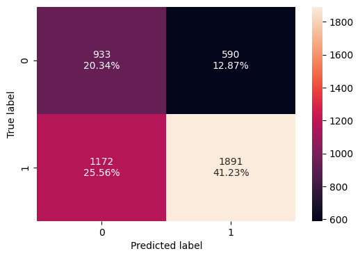

```python
confusion_matrix_sklearn(dtree_under,X_val,y_val)
```

##### Bagging Classifier

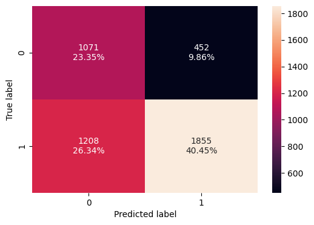

```python
confusion_matrix_sklearn(bagging_under,X_val,y_val)
```

##### Random Forest Classifier

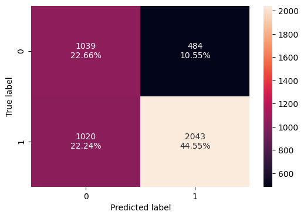

```python
confusion_matrix_sklearn(randomf_under,X_val,y_val)
```

##### Boosting Classifier

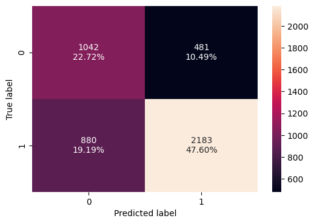

```python
confusion_matrix_sklearn(gradient_under,X_val,y_val)
```

##### Adaboost Classifier

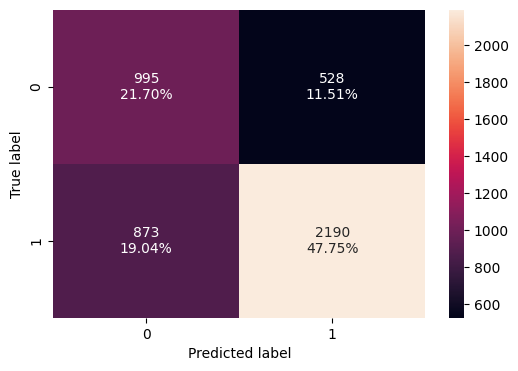

```python
confusion_matrix_sklearn(adaboost_under,X_val,y_val)
```

##### XGB Classifier

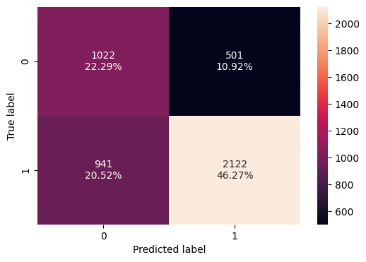

```python
confusion_matrix_sklearn(xgbboost_under,X_val,y_val)
```

### Observations on training and validation set performance for the Precision Metric for the undersampled data

- The performance for the validation set has increased slightly in the models with undersampled data vs the models with original data but in case of Precision is still around 80%.
- For the training set, the top tree models for undersampled data are : 1)Undersampled Decision Tree (Precision 1) , 2) Undersampled Random Forest (Precision:1) and 3) Undersampled Bagging Classifier (Precision:0.991366)
- For the validation set, the top tree models for undersampled data are : 1) Undersampled Boosting Classifier (Precision:0.819444), 2) Undersampled XGB Classifier (Precision: 0.808997), 3) Undersampled Random Forest Classifier (Precision: 0.808469)

```python
scores_training_under_df.sort_values(by="Precision", ascending=False)
```

|  | model | Accuracy | Recall | Precision | F1 |
| --- | --- | --- | --- | --- | --- |
| 0 | Undersampled Decision Tree - Training | 1.000000 | 1.000000 | 1.000000 | 1.000000 |
| 2 | Undersampled Random Forest Classifier - Training | 1.000000 | 1.000000 | 1.000000 | 1.000000 |
| 1 | Undersampled Bagging Classifier - Training | 0.980415 | 0.969272 | 0.991366 | 0.980195 |
| 5 | Undersampled XGB Classifier - Training | 0.855732 | 0.859699 | 0.852931 | 0.856302 |
| 3 | Undersampled Boosting Classifier - Training | 0.722860 | 0.729529 | 0.719927 | 0.724696 |
| 4 | Undersampled AdaBoost Classifier - Training | 0.700152 | 0.719061 | 0.692858 | 0.705717 |

```python
scores_validation_under_df.sort_values(by="Precision", ascending=False)
```

|  | model | Accuracy | Recall | Precision | F1 |
| --- | --- | --- | --- | --- | --- |
| 3 | Undersampled Boosting Classifier - Validation | 0.703227 | 0.712700 | 0.819444 | 0.762354 |
| 5 | Undersampled XGB Classifier - Validation | 0.685565 | 0.692785 | 0.808997 | 0.746395 |
| 2 | Undersampled Random Forest Classifier - Valida... | 0.672045 | 0.666993 | 0.808469 | 0.730948 |
| 4 | Undersampled AdaBoost Classifier - Validation | 0.694505 | 0.714985 | 0.805740 | 0.757654 |
| 1 | Undersampled Bagging Classifier - Validation | 0.638029 | 0.605615 | 0.804075 | 0.690875 |
| 0 | Undersampled Decision Tree - Validation | 0.615787 | 0.617369 | 0.762193 | 0.682179 |

# Training Scores for all models in the dataset

```python
combined_training_df=pd.DataFrame(columns=["model", "Accuracy","Recall","Precision","F1"])
combined_training_df = pd.concat([scores_training_original_df, scores_training_over_df, scores_training_under_df],ignore_index=True)
combined_training_df.sort_values(by="Precision", ascending=False)
```

|  | model | Accuracy | Recall | Precision | F1 |
| --- | --- | --- | --- | --- | --- |
| 0 | Decision Tree - Training | 1.000000 | 1.000000 | 1.000000 | 1.000000 |
| 2 | Random Forest Classifier - Training | 0.999944 | 0.999916 | 1.000000 | 0.999958 |
| 14 | Undersampled Random Forest Classifier - Training | 1.000000 | 1.000000 | 1.000000 | 1.000000 |
| 6 | Oversampled Decision Tree - Training | 1.000000 | 1.000000 | 1.000000 | 1.000000 |
| 8 | Oversampled Random Forest Classifier - Training | 1.000000 | 1.000000 | 1.000000 | 1.000000 |
| 12 | Undersampled Decision Tree - Training | 1.000000 | 1.000000 | 1.000000 | 1.000000 |
| 1 | Bagging Classifier - Training | 0.985198 | 0.985982 | 0.991810 | 0.988887 |
| 13 | Undersampled Bagging Classifier - Training | 0.980415 | 0.969272 | 0.991366 | 0.980195 |
| 7 | Oversampled Bagging Classifier - Training | 0.985940 | 0.980442 | 0.991343 | 0.985862 |
| 11 | Oversampled XGB Classifier - Training | 0.875598 | 0.903719 | 0.855599 | 0.879001 |
| 5 | XGB Classifier - Training | 0.850807 | 0.935952 | 0.854537 | 0.893394 |
| 17 | Undersampled XGB Classifier - Training | 0.855732 | 0.859699 | 0.852931 | 0.856302 |
| 9 | Oversampled Boosting Classifier - Training | 0.801687 | 0.825149 | 0.788165 | 0.806233 |
| 3 | Boosting Classifier - Training | 0.758802 | 0.883740 | 0.783042 | 0.830349 |
| 10 | Oversampled AdaBoost Classifier - Training | 0.779862 | 0.816083 | 0.760958 | 0.787557 |
| 4 | AdaBoost Classifier - Training | 0.738226 | 0.887182 | 0.760688 | 0.819080 |
| 15 | Undersampled Boosting Classifier - Training | 0.722860 | 0.729529 | 0.719927 | 0.724696 |
| 16 | Undersampled AdaBoost Classifier - Training | 0.700152 | 0.719061 | 0.692858 | 0.705717 |

# Validation Scores for all models in the dataset

```python
combined_validation_df=pd.DataFrame(columns=["model", "Accuracy","Recall","Precision","F1"])
combined_validation_df = pd.concat([scores_validation_original_df, scores_validation_over_df, scores_validation_under_df],ignore_index=True)
combined_validation_df.sort_values(by="Precision", ascending=False)
```

|  | model | Accuracy | Recall | Precision | F1 |
| --- | --- | --- | --- | --- | --- |
| 15 | Undersampled Boosting Classifier - Validation | 0.703227 | 0.712700 | 0.819444 | 0.762354 |
| 17 | Undersampled XGB Classifier - Validation | 0.685565 | 0.692785 | 0.808997 | 0.746395 |
| 14 | Undersampled Random Forest Classifier - Valida... | 0.672045 | 0.666993 | 0.808469 | 0.730948 |
| 16 | Undersampled AdaBoost Classifier - Validation | 0.694505 | 0.714985 | 0.805740 | 0.757654 |
| 13 | Undersampled Bagging Classifier - Validation | 0.638029 | 0.605615 | 0.804075 | 0.690875 |
| 9 | Oversampled Boosting Classifier - Validation | 0.725687 | 0.818152 | 0.781416 | 0.799362 |
| 7 | Oversampled Bagging Classifier - Validation | 0.692543 | 0.749265 | 0.781410 | 0.765000 |
| 8 | Oversampled Random Forest Classifier - Validation | 0.711295 | 0.801502 | 0.774204 | 0.787616 |
| 1 | Bagging Classifier - Validation | 0.694069 | 0.765916 | 0.773747 | 0.769811 |
| 11 | Oversampled XGB Classifier - Validation | 0.717401 | 0.817826 | 0.772433 | 0.794481 |
| 3 | Boosting Classifier - Validation | 0.743567 | 0.880836 | 0.768880 | 0.821059 |
| 5 | XGB Classifier - Validation | 0.728304 | 0.848841 | 0.768549 | 0.806702 |
| 2 | Random Forest Classifier - Validation | 0.718927 | 0.832191 | 0.766847 | 0.798184 |
| 12 | Undersampled Decision Tree - Validation | 0.615787 | 0.617369 | 0.762193 | 0.682179 |
| 10 | Oversampled AdaBoost Classifier - Validation | 0.700611 | 0.809990 | 0.758252 | 0.783268 |
| 0 | Decision Tree - Validation | 0.667684 | 0.741103 | 0.756415 | 0.748681 |
| 6 | Oversampled Decision Tree - Validation | 0.660488 | 0.726412 | 0.755774 | 0.740802 |
| 4 | AdaBoost Classifier - Validation | 0.730484 | 0.887365 | 0.753117 | 0.814748 |

## Hyperparameter Tuning

### Summarization for selecting 3 models hyperparameter tuning.

- Taking into account the information above and the fact that I need to select 3 models, the top 3 performing models according to the validation scores are:
  - 1. Undersampled Boosting Classifier (Precision:0.819444)
  - 2. Undersampled XGB Classifier (Precision:0.808997)
  - 3. Undersampled Random Forest Classifier (Precision:0.808469)

Let's define the dataframes for the training and validation scores for the 3 models to tune

```python
#DataFrame that saves the model along with the cv score for the training set and the precision metric for the validation set
results_df_tuned = []
results_df_tuned  = pd.DataFrame(columns=["model", "mean of cv_score training set","precision validation set"])
```

### Model 1: Undersampled Boosting Classifier - Validation (Precision:0.819444)

**Best practices for hyperparameter tuning in Gradient Boosting:**

`n_estimators`:

- Start with 100 (default) and increase: 100, 200, 300, 500
- Typically, higher values lead to better performance, but they also increase training time
- Use 200–500 for larger datasets or complex problems
- Monitor validation performance to avoid overfitting, as too many estimators can degrade generalization

`learning_rate`:

- Common values to try: 0.1, 0.05, 0.01, 0.005
- Use lower values (e.g., 0.01 or 0.005) if you are using many estimators (e.g., > 200)
- Higher learning rates (e.g., 0.1) can be used with fewer estimators for faster convergence
- Always balance the learning rate with `n_estimators` to prevent overfitting or underfitting

`subsample`:

- Common values: 0.7, 0.8, 0.9, 1.0
- Use a value between `0.7` and `0.9` for improved generalization by introducing randomness
- `1.0` uses the full dataset for each boosting round, potentially leading to overfitting
- Reducing `subsample` can help reduce overfitting, especially in smaller datasets

`max_features`:

- Common values: `"sqrt"`, `"log2"`, or float (e.g., `0.3`, `0.5`)
- `"sqrt"` (default) works well for classification tasks
- Lower values (e.g., `0.3`) help reduce overfitting by limiting the number of features considered at each split

#### Let's define the dataframes needed to store the performance on training and validation for the selected models

```python
scores_training_tuning_df = []
scores_validation_tuning_df = []
scores_training_tuning_df = pd.DataFrame(columns=["model", "Accuracy","Recall","Precision","F1"])
scores_validation_tuning_df = pd.DataFrame(columns=["model", "Accuracy","Recall","Precision","F1"])
```

#### Let's use Randomize Search CV for Model 1

```python
# Choose the type of classifier.
m1 = GradientBoostingClassifier(random_state=1)

# Grid of parameters to choose from
parameters = {
    "init": [AdaBoostClassifier(random_state=1),DecisionTreeClassifier(random_state=1)],
    "n_estimators": np.arange(100, 300, 25),
    "learning_rate": np.arange(0.1, 1, 0.05),
    "subsample": np.arange(0.7, 0.9, 0.05),
    "max_features": np.arange(0.5, 1, 0.1),
    "max_depth": [3, 4, 5, 6, 7],
    "min_samples_split": [2, 5, 10],
    "min_samples_leaf": [1, 2, 4]
}

# Type of scoring used to compare parameter combinations
acc_scorer = metrics.make_scorer(metrics.precision_score)

# Run the random search
grid_obj = RandomizedSearchCV(m1, parameters,n_iter=60, scoring=acc_scorer,cv=kfold, random_state = 1, n_jobs = -1, verbose = 2)
# using n_iter = 60, so randomized search will try 60 different combinations of hyperparameters
# by default, n_iter = 10

grid_obj = grid_obj.fit(X_train_un, y_train_un)

# Print the best combination of parameters
grid_obj.best_params_
```

```
Fitting 10 folds for each of 60 candidates, totalling 600 fits
```

```
{'subsample': 0.75,
 'n_estimators': 125,
 'min_samples_split': 10,
 'min_samples_leaf': 4,
 'max_features': 0.7,
 'max_depth': 3,
 'learning_rate': 0.1,
 'init': AdaBoostClassifier(random_state=1)}
```

#### Let's check the best CV score

```python
grid_obj.best_score_
```

```
0.7085094682000934
```

#### Let's create a model with the parameters above

```python
#Gradient Boosting Classifier

gradient_tuned_randomized=GradientBoostingClassifier(random_state=1,subsample= 0.75,n_estimators= 125,min_samples_split= 10,min_samples_leaf= 4,
                                            max_features= 0.7,max_depth= 3,learning_rate=0.1,init= AdaBoostClassifier(random_state=1))
#Fit the training set

gradient_tuned_randomized.fit(X_train_un,y_train_un)

# Get the cross validation scores
results = cross_val_score(gradient_tuned_randomized, X_train_un, y_train_un, cv=kfold, scoring=scorer_value)

# Get the precision for the validation data

precision=precision_score(y_val, gradient_tuned_randomized.predict(X_val))

print("The precision of the validation set for the model tuned with the output of the Randomized Search is", precision)

# Add the mode, the cross validation mean and the precision on the validation set to a dataframe

results_df_tuned = results_df_tuned._append({"model": "Tuned Gradient Boosting Classifier - Undersampled - Randomized Search", "mean of cv_score training set": results.mean(),"precision validation set": precision}, ignore_index=True)
```

```
The precision of the validation set for the model tuned with the output of the Randomized Search is 0.8190229459659512
```

- Given the precision on the validation set is less than the precision on the model without tuning, I will implement GridSearch with a set of parameters with values around the values selected by RandomizedSearch to see if I can improve the Precision on the validation set.

#### Let's use GridSearch with a subset around the values of the parameters above

```python
# Choose the type of classifier.
m1 = GradientBoostingClassifier(random_state=1)

parameters = {
     "init": [AdaBoostClassifier(random_state=1)],
    "n_estimators": [100, 125,150],
    "learning_rate": [0.1, 0.2],
    "subsample": [0.7, 0.8],
    "max_features": [0.6, 0.8],
    "max_depth": [3,5],
    "min_samples_split": [10],
    "min_samples_leaf": [4,7,10]
}

# Type of scoring used to compare parameter combinations
acc_scorer = metrics.make_scorer(metrics.precision_score)

# Run the random search
grid_obj = GridSearchCV(m1, parameters, scoring=acc_scorer,cv=3, n_jobs = -1, verbose = 2)

# by default, n_iter = 10

grid_obj = grid_obj.fit(X_train_un, y_train_un)

# Print the best combination of parameters
grid_obj.best_params_
```

```
Fitting 3 folds for each of 144 candidates, totalling 432 fits
```

```
{'init': AdaBoostClassifier(random_state=1),
 'learning_rate': 0.1,
 'max_depth': 3,
 'max_features': 0.6,
 'min_samples_leaf': 4,
 'min_samples_split': 10,
 'n_estimators': 125,
 'subsample': 0.7}
```

```python
grid_obj.best_score_
```

```
0.7108513851214641
```

- The best score increased so we will create a model with those latest parameters and check the precision score for the validation set.

#### Let's create a model with the parameters above

```python
#Gradient Boosting Classifier with the GridSearch parameters

gradient_tuned=GradientBoostingClassifier(random_state=1,subsample= 0.7,n_estimators=125,min_samples_split= 10,
                                          min_samples_leaf= 4,max_features=0.6,max_depth= 3,learning_rate= 0.1,init= AdaBoostClassifier(random_state=1))
#Fit the training set

gradient_tuned.fit(X_train_un,y_train_un)

# Get the cross validation scores
results = cross_val_score(gradient_tuned, X_train_un, y_train_un, cv=kfold, scoring=scorer_value)

# Get the precision for the validation data

precision=precision_score(y_val, gradient_tuned.predict(X_val))

# Add the mode, the cross validation mean and the precision on the validation set to a dataframe

print("The precision of the validation set for the model tuned with the output of the Grid Search is", precision)

results_df_tuned = results_df_tuned._append({"model": "Tuned Gradient Boosting Classifier - Undersampled - Grid Search", "mean of cv_score training set": results.mean(),"precision validation set": precision}, ignore_index=True)
```

```
The precision of the validation set for the model tuned with the output of the Grid Search is 0.821656050955414
```

```python
results_df_tuned
```

|  | model | mean of cv_score training set | precision validation set |
| --- | --- | --- | --- |
| 0 | Tuned Gradient Boosting Classifier - Undersampled - Randomized Search | 0.708509 | 0.819023 |
| 1 | Tuned Gradient Boosting Classifier - Undersampled - Grid Search | 0.706644 | 0.821656 |

#### Let's get the model performance in training and validation sets for Model 1 with RandomizedSearch and with GridSearch

```python
# Bagging Classifier Training Set
m1_perfm_t=model_performance_classification_sklearn(gradient_tuned_randomized,X_train_un,y_train_un)
scores_training_tuning_df = add_scores(scores_training_tuning_df, m1_perfm_t, "Hypertunning - Model 1 Boosting Classifier - Randomized - Undersampled - Training")

# Bagging Classifier Validation Set
m1_perfm_v=model_performance_classification_sklearn(gradient_tuned_randomized,X_val,y_val)
scores_validation_tuning_df = add_scores(scores_validation_tuning_df, m1_perfm_v, "Hypertunning - Model 1 Boosting Classifier  - -Randomized -  Undersampled - Validation")
```

```python
# Bagging Classifier Training Set
m1_perfm_t=model_performance_classification_sklearn(gradient_tuned,X_train_un,y_train_un)
scores_training_tuning_df = add_scores(scores_training_tuning_df, m1_perfm_t, "Hypertunning - Model 1 Boosting Classifier - GridSearch -  Undersampled - Training")

# Bagging Classifier Validation Set
m1_perfm_v=model_performance_classification_sklearn(gradient_tuned,X_val,y_val)
scores_validation_tuning_df = add_scores(scores_validation_tuning_df, m1_perfm_v, "Hypertunning - Model 1 Boosting Classifier - GridSearch -  Undersampled - Validation")
```

```python
scores_training_tuning_df
```

|  | model | Accuracy | Recall | Precision | F1 |
| --- | --- | --- | --- | --- | --- |
| 0 | Hypertunning - Model 1 Boosting Classifier - Randomized - Undersampled - Training | 0.726490 | 0.739152 | 0.720896 | 0.72991 |
| 1 | Hypertunning - Model 1 Boosting Classifier - GridSearch - Undersampled - Training | 0.725899 | 0.733919 | 0.722333 | 0.72808 |

```python
scores_validation_tuning_df
```

|  | model | Accuracy | Recall | Precision | F1 |
| --- | --- | --- | --- | --- | --- |
| 0 | Hypertunning - Model 1 Boosting Classifier - -Randomized - Undersampled - Validation | 0.708024 | 0.722494 | 0.819023 | 0.767736 |
| 1 | Hypertunning - Model 1 Boosting Classifier - GridSearch - Undersampled - Validation | 0.706498 | 0.715965 | 0.821656 | 0.765178 |

### Model 2: Undersampled XGB Classifier (Validation Set Precision:0.808997)

**Best practices for hyperparameter tuning in XGBoost:**

`n_estimators`:

- Start with 50 and increase in steps: 50,75,100,125.
- Use more estimators (e.g., 150-250) when using lower learning rates
- Monitor validation performance
- High values improve learning but increase training time

`subsample`:

- Common values: 0.5, 0.7, 0.8, 1.0
- Use `0.7–0.9` to introduce randomness and reduce overfitting
- `1.0` uses the full dataset in each boosting round; may overfit on small datasets
- Values < 0.5 are rarely useful unless dataset is very large

`gamma`:

- Try values: 0 (default), 1, 3, 5, 8
- Controls minimum loss reduction needed for a split
- Higher values make the algorithm more conservative (i.e., fewer splits)
- Use values > 0 to regularize and reduce overfitting, especially on noisy data

`colsample_bytree`:

- Try values: 0.3, 0.5, 0.7, 1.0
- Fraction of features sampled per tree
- Lower values (e.g., 0.3 or 0.5) increase randomness and improve generalization
- Use `1.0` when you want all features considered for every tree

`colsample_bylevel`:

- Try values: 0.3, 0.5, 0.7, 1.0
- Fraction of features sampled at each tree level (i.e., per split depth)
- Lower values help in regularization and reducing overfitting
- Often used in combination with `colsample_bytree` for fine control over feature sampling

#### Let's use Randomize Search CV for Model 2

```python
# Choose the type of classifier.
m2 = XGBClassifier(random_state=1)

parameters = {
    "n_estimators": np.arange(50, 300, 25),
    "subsample": np.arange(0.7, 0.9, 0.05),
    "gamma":np.arange(1,8,1),
    "colsample_bytree": np.arange(0.3,0.9,0.01),
    "colsample_bylevel": np.arange(0.3,0.9,0.02)
}


# Type of scoring used to compare parameter combinations
acc_scorer = metrics.make_scorer(metrics.precision_score)

# Run the random search
grid_obj = RandomizedSearchCV(m2, parameters,n_iter=60, scoring=acc_scorer,cv=kfold, random_state = 1, n_jobs = -1, verbose = 2)
# using n_iter = 60, so randomized search will try 60 different combinations of hyperparameters
# by default, n_iter = 10

grid_obj = grid_obj.fit(X_train_un, y_train_un)

# Print the best combination of parameters
grid_obj.best_params_
```

```
Fitting 10 folds for each of 60 candidates, totalling 600 fits
```

```
{'subsample': 0.9000000000000001,
 'n_estimators': 200,
 'gamma': 3,
 'colsample_bytree': 0.5400000000000003,
 'colsample_bylevel': 0.7400000000000004}
```

```python
grid_obj.best_score_
```

```
0.7083501805971479
```

#### Let's create a model with the parameters above

```python
#XGB Classifier

xgb_tuned=XGBClassifier(random_state=1,subsample= 0.9000000000000001,n_estimators= 200,gamma=3,colsample_bytree= 0.5400000000000003,
                        colsample_bylevel=0.7400000000000004)

#Fit the training set

xgb_tuned.fit(X_train_un,y_train_un)

# Get the cross validation scores
results = cross_val_score(xgb_tuned, X_train_un, y_train_un, cv=kfold, scoring=scorer_value)

# Get the precision for the validation data

precision=precision_score(y_val, xgb_tuned.predict(X_val))

print("The precision of the validation set for the model tuned with the output of the Randomized Search is", precision)

# Add the mode, the cross validation mean and the precision on the validation set to a dataframe
results_df_tuned = results_df_tuned._append({"model": "Tuned XGB Classifier - Undersampled Data ", "mean of cv_score training set": results.mean(),"precision validation set": precision}, ignore_index=True)
```

```
The precision of the validation set for the model tuned with the output of the Randomized Search is 0.8155375552282769
```

```python
results_df_tuned
```

|  | model | mean of cv_score training set | precision validation set |
| --- | --- | --- | --- |
| 0 | Tuned Gradient Boosting Classifier - Undersampled - Randomized Search | 0.708509 | 0.819023 |
| 1 | Tuned Gradient Boosting Classifier - Undersampled - Grid Search | 0.706644 | 0.821656 |
| 2 | Tuned XGB Classifier - Undersampled Data | 0.708350 | 0.815538 |

#### Let's get the model performance in training and validation sets for Model 2

```python
# Bagging Classifier Training Set
m2_perfm_t=model_performance_classification_sklearn(xgb_tuned,X_train_un,y_train_un)
scores_training_tuning_df = add_scores(scores_training_tuning_df, m2_perfm_t, "Hypertunning - Model 2 XGB Classifier - Undersampled - Training")

# Bagging Classifier Validation Set
m2_perfm_v=model_performance_classification_sklearn(xgb_tuned,X_val,y_val)
scores_validation_tuning_df = add_scores(scores_validation_tuning_df, m2_perfm_v, "Hypertunning - Model 2 XGB Classifier - Undersampled - Validation")
```

```python
scores_training_tuning_df
```

|  | model | Accuracy | Recall | Precision | F1 |
| --- | --- | --- | --- | --- | --- |
| 0 | Hypertunning - Model 1 Boosting Classifier - Randomized - Undersampled - Training | 0.726490 | 0.739152 | 0.720896 | 0.729910 |
| 1 | Hypertunning - Model 1 Boosting Classifier - GridSearch - Undersampled - Training | 0.725899 | 0.733919 | 0.722333 | 0.728080 |
| 2 | Hypertunning - Model 2 XGB Classifier - Undersampled - Training | 0.732146 | 0.743204 | 0.727123 | 0.735076 |

```python
scores_validation_tuning_df
```

|  | model | Accuracy | Recall | Precision | F1 |
| --- | --- | --- | --- | --- | --- |
| 0 | Hypertunning - Model 1 Boosting Classifier - -Randomized - Undersampled - Validation | 0.708024 | 0.722494 | 0.819023 | 0.767736 |
| 1 | Hypertunning - Model 1 Boosting Classifier - GridSearch - Undersampled - Validation | 0.706498 | 0.715965 | 0.821656 | 0.765178 |
| 2 | Hypertunning - Model 2 XGB Classifier - Undersampled - Validation | 0.705844 | 0.723147 | 0.815538 | 0.766569 |

### Model 3: Undersampled Random Forest Classifier (Precision:0.808469)

**Best practices for hyperparameter tuning in Random Forest:**

`n_estimators`:

- Start with a specific number (50 is used in general) and increase in steps: 50, 75, 100, 125
- Higher values generally improve performance but increase training time
- Use 100-150 for large datasets or when variance is high

`min_samples_leaf`:

- Try values like: 1, 2, 4, 5, 10
- Higher values reduce model complexity and help prevent overfitting
- Use 1–2 for low-bias models, higher (like 5 or 10) for more regularized models
- Works well in noisy datasets to smooth predictions

`max_features`:

- Try values: `"sqrt"` (default for classification), `"log2"`, `None`, or float values (e.g., `0.3`, `0.5`)
- `"sqrt"` balances between diversity and performance for classification tasks
- Lower values (e.g., `0.3`) increase tree diversity, reducing overfitting
- Higher values (closer to `1.0`) may capture more interactions but risk overfitting

`max_samples` (for bootstrap sampling):

- Try float values between `0.5` to `1.0` or fixed integers
- Use `0.6–0.9` to introduce randomness and reduce overfitting
- Smaller values increase diversity between trees, improving generalization

#### Let's use Randomize Search CV for Model 3

```python
# Choose the type of classifier.
m3 = RandomForestClassifier(random_state=1)

# Grid of parameters to choose from
parameters = {"n_estimators": [150,200,250],
    "min_samples_leaf": np.arange(5, 10),
    "max_features": np.arange(0.2, 0.7, 0.1),
    "max_samples": np.arange(0.3, 0.7, 0.1),
    "class_weight" : ['balanced', 'balanced_subsample'],
    "max_depth":np.arange(3,4,5),
    "min_impurity_decrease":[0.001, 0.002, 0.003]
             }

# Type of scoring used to compare parameter combinations
acc_scorer = metrics.make_scorer(metrics.precision_score)

# Run the random search
grid_obj = RandomizedSearchCV(m3, parameters,n_iter=60, scoring=acc_scorer,cv=kfold, random_state = 1, n_jobs = -1, verbose = 2)
# using n_iter = 60, so randomized search will try 60 different combinations of hyperparameters
# by default, n_iter = 10

grid_obj = grid_obj.fit(X_train_un, y_train_un)

# Print the best combination of parameters
grid_obj.best_params_
```

```
Fitting 10 folds for each of 60 candidates, totalling 600 fits
```

```
{'n_estimators': 150,
 'min_samples_leaf': 9,
 'min_impurity_decrease': 0.003,
 'max_samples': 0.5,
 'max_features': 0.6000000000000001,
 'max_depth': 3,
 'class_weight': 'balanced'}
```

```python
grid_obj.best_score_
```

```
0.7001206938904911
```

#### Let's create a model with the parameters above

```python
#Random Forest Classifier Tuned

randomf_tuned=RandomForestClassifier(random_state=1,n_estimators=150,min_samples_leaf= 9,min_impurity_decrease =0.003,max_samples= 0.5,
                                     max_features=0.6000000000000001,max_depth= 3,class_weight='balanced')

#Fit the training set

randomf_tuned.fit(X_train_un,y_train_un)

# Get the cross validation scores
results = cross_val_score(randomf_tuned, X_train_un, y_train_un, cv=kfold, scoring=scorer_value)

# Get the precision for the validation data

precision=precision_score(y_val, randomf_tuned.predict(X_val))

print("The precision of the validation set for the model tuned with the output of the Randomized Search is", precision)

# Add the mode, the cross validation mean and the precision on the validation set to a dataframe

results_df_tuned = results_df_tuned._append({"model": "Tuned Random Forest Classifier - UnderSampled Data ", "mean of cv_score training set": results.mean(),"precision validation set": precision}, ignore_index=True)
```

```
The precision of the validation set for the model tuned with the output of the Randomized Search is 0.821711270260083
```

```python
results_df_tuned
```

|  | model | mean of cv_score training set | precision validation set |
| --- | --- | --- | --- |
| 0 | Tuned Gradient Boosting Classifier - Undersampled - Randomized Search | 0.708509 | 0.819023 |
| 1 | Tuned Gradient Boosting Classifier - Undersampled - Grid Search | 0.706644 | 0.821656 |
| 2 | Tuned XGB Classifier - Undersampled Data | 0.708350 | 0.815538 |
| 3 | Tuned Random Forest Classifier - UnderSampled Data | 0.700121 | 0.821711 |

#### Let's get the model performance in training and validation sets for Model 3

```python
#Random Forest Training Set
m3_perfm_t=model_performance_classification_sklearn(randomf_tuned,X_train_un,y_train_un)
scores_training_tuning_df = add_scores(scores_training_tuning_df, m3_perfm_t, "Hypertunning - Model 3 Random Forest Classifier - Undersampled - Training")

#Random Forest  Validation Set
m3_perfm_v=model_performance_classification_sklearn(randomf_tuned,X_val,y_val)
scores_validation_tuning_df = add_scores(scores_validation_tuning_df, m3_perfm_v, "Hypertunning -  Model 3 Random Forest Classifier - Undersampled - Validation")
```

```python
scores_training_tuning_df
```

|  | model | Accuracy | Recall | Precision | F1 |
| --- | --- | --- | --- | --- | --- |
| 0 | Hypertunning - Model 1 Boosting Classifier - Randomized - Undersampled - Training | 0.726490 | 0.739152 | 0.720896 | 0.729910 |
| 1 | Hypertunning - Model 1 Boosting Classifier - GridSearch - Undersampled - Training | 0.725899 | 0.733919 | 0.722333 | 0.728080 |
| 2 | Hypertunning - Model 2 XGB Classifier - Undersampled - Training | 0.732146 | 0.743204 | 0.727123 | 0.735076 |
| 3 | Hypertunning - Model 3 Random Forest Classifier - Undersampled - Training | 0.702094 | 0.705555 | 0.700704 | 0.703121 |

```python
scores_validation_tuning_df
```

|  | model | Accuracy | Recall | Precision | F1 |
| --- | --- | --- | --- | --- | --- |
| 0 | Hypertunning - Model 1 Boosting Classifier - -Randomized - Undersampled - Validation | 0.708024 | 0.722494 | 0.819023 | 0.767736 |
| 1 | Hypertunning - Model 1 Boosting Classifier - GridSearch - Undersampled - Validation | 0.706498 | 0.715965 | 0.821656 | 0.765178 |
| 2 | Hypertunning - Model 2 XGB Classifier - Undersampled - Validation | 0.705844 | 0.723147 | 0.815538 | 0.766569 |
| 3 | Hypertunning - Model 3 Random Forest Classifier - Undersampled - Validation | 0.704317 | 0.711721 | 0.821711 | 0.762771 |

#### Let's check the confusion matrix for the 4 models on the validation set

##### Tuned Gradient Boosting Classifier - Undersampled dataset - Randomized Search

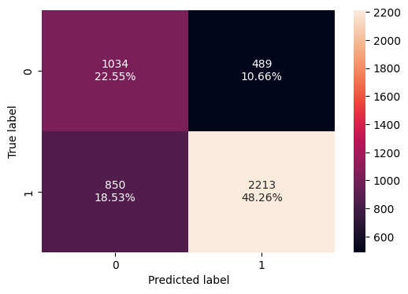

```python
confusion_matrix_sklearn(gradient_tuned_randomized,X_val,y_val)
```

##### Tuned Gradient Boosting Classifier - Grid Search - Undersampled dataset

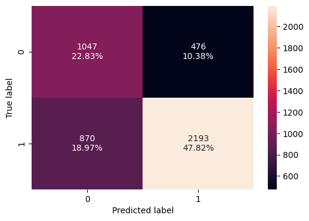

```python
confusion_matrix_sklearn(gradient_tuned,X_val,y_val)
```

##### XGB Classifier - Undersampled dataset

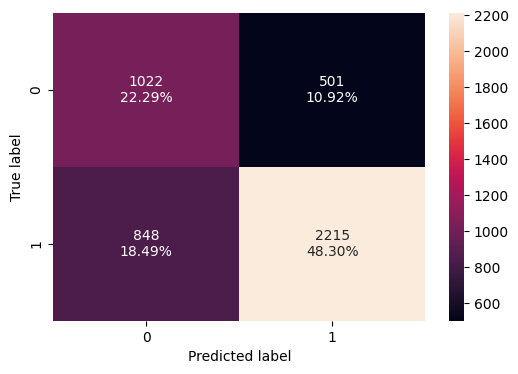

```python
confusion_matrix_sklearn(xgb_tuned,X_val,y_val)
```

##### Random Forest Classifier - Undersampled dataset

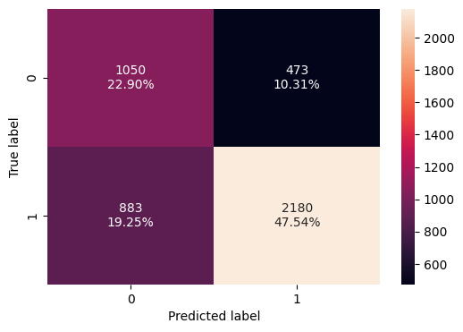

```python
confusion_matrix_sklearn(randomf_tuned,X_val,y_val)
```

## Model Performance Summary and Final Model Selection

- As we can see , the model with the best Precision metric is the Hypertunning - Model 3 Random Forest Classification with a precision for the validation set of 0.821711. We will now see what are the metrics for this model in the testing set.

```python
combined_validation_df=pd.DataFrame(columns=["model", "Accuracy","Recall","Precision","F1"])
combined_validation_df = pd.concat([scores_validation_original_df, scores_validation_over_df, scores_validation_under_df,scores_validation_tuning_df],ignore_index=True)
combined_validation_df.sort_values(by="Precision", ascending=False)
```

|  | model | Accuracy | Recall | Precision | F1 |
| --- | --- | --- | --- | --- | --- |
| 21 | Hypertunning - Model 3 Random Forest Classifier - Undersampled - Validation | 0.704317 | 0.711721 | 0.821711 | 0.762771 |
| 19 | Hypertunning - Model 1 Boosting Classifier - GridSearch - Undersampled - Validation | 0.706498 | 0.715965 | 0.821656 | 0.765178 |
| 15 | Undersampled Boosting Classifier - Validation | 0.703227 | 0.712700 | 0.819444 | 0.762354 |
| 18 | Hypertunning - Model 1 Boosting Classifier - -Randomized - Undersampled - Validation | 0.708024 | 0.722494 | 0.819023 | 0.767736 |
| 20 | Hypertunning - Model 2 XGB Classifier - Undersampled - Validation | 0.705844 | 0.723147 | 0.815538 | 0.766569 |
| 17 | Undersampled XGB Classifier - Validation | 0.685565 | 0.692785 | 0.808997 | 0.746395 |
| 14 | Undersampled Random Forest Classifier - Validation | 0.672045 | 0.666993 | 0.808469 | 0.730948 |
| 16 | Undersampled AdaBoost Classifier - Validation | 0.694505 | 0.714985 | 0.805740 | 0.757654 |
| 13 | Undersampled Bagging Classifier - Validation | 0.638029 | 0.605615 | 0.804075 | 0.690875 |
| 9 | Oversampled Boosting Classifier - Validation | 0.725687 | 0.818152 | 0.781416 | 0.799362 |
| 7 | Oversampled Bagging Classifier - Validation | 0.692543 | 0.749265 | 0.781410 | 0.765000 |
| 8 | Oversampled Random Forest Classifier - Validation | 0.711295 | 0.801502 | 0.774204 | 0.787616 |
| 1 | Bagging Classifier - Validation | 0.694069 | 0.765916 | 0.773747 | 0.769811 |
| 11 | Oversampled XGB Classifier - Validation | 0.717401 | 0.817826 | 0.772433 | 0.794481 |
| 3 | Boosting Classifier - Validation | 0.743567 | 0.880836 | 0.768880 | 0.821059 |
| 5 | XGB Classifier - Validation | 0.728304 | 0.848841 | 0.768549 | 0.806702 |
| 2 | Random Forest Classifier - Validation | 0.718927 | 0.832191 | 0.766847 | 0.798184 |
| 12 | Undersampled Decision Tree - Validation | 0.615787 | 0.617369 | 0.762193 | 0.682179 |
| 10 | Oversampled AdaBoost Classifier - Validation | 0.700611 | 0.809990 | 0.758252 | 0.783268 |
| 0 | Decision Tree - Validation | 0.667684 | 0.741103 | 0.756415 | 0.748681 |
| 6 | Oversampled Decision Tree - Validation | 0.660488 | 0.726412 | 0.755774 | 0.740802 |
| 4 | AdaBoost Classifier - Validation | 0.730484 | 0.887365 | 0.753117 | 0.814748 |

### Let's check the performance of the selected model in the testing set.

```python
test_df = model_performance_classification_sklearn(randomf_tuned, X_test, y_test)
test_df
```

|  | Accuracy | Recall | Precision | F1 |
| --- | --- | --- | --- | --- |
| 0 | 0.699804 | 0.703722 | 0.821143 | 0.757911 |

- As we can see the model is generalizing well and the precision value in the test set is very close to the precision value in the validation set.

### Let's check the confusion matrix for test

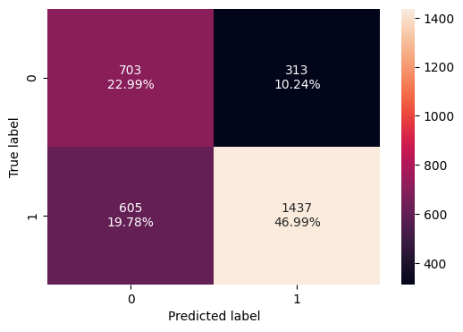

```python
confusion_matrix_sklearn(randomf_tuned,X_test,y_test)
```

### Feature importances

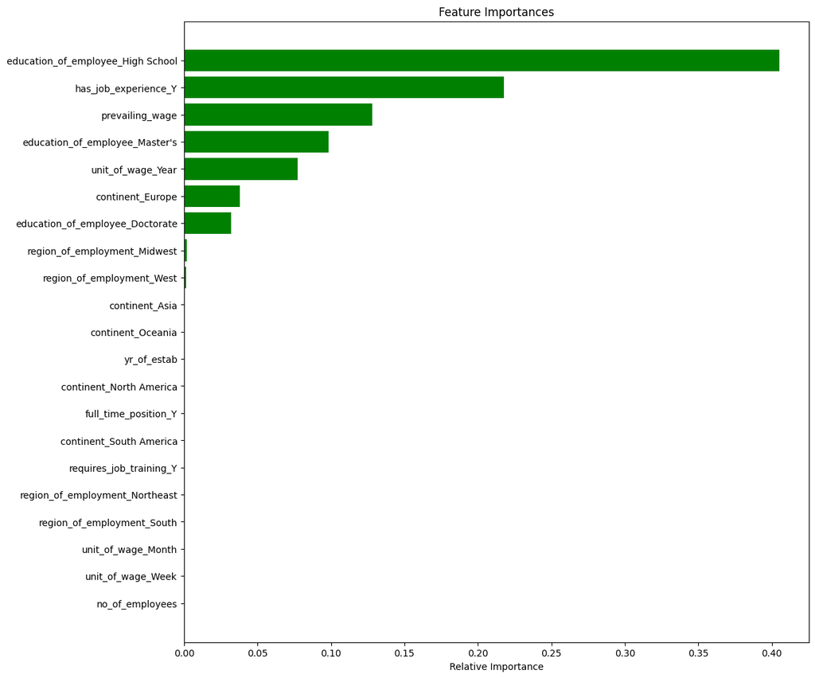

```python
importances = randomf_tuned.feature_importances_
indices = np.argsort(importances)
feature_names = list(X_train.columns)

plt.figure(figsize=(12,12))
plt.title('Feature Importances')
plt.barh(range(len(indices)), importances[indices], color='green', align='center')
plt.yticks(range(len(indices)), [feature_names[i] for i in indices])
plt.xlabel('Relative Importance')
plt.show()
```

- Education_High_School, having job experience and prevailing wage are the main features for the selected model.

## Actionable Insights and Recommendations

### Insights

Observations on Data:

- The dataset has 25480 rows and 12 columns. Out of them there are 9 categorical columns, 2 integer columns and one float column.
- The object columns were converted to category to take advantage of the benefits that this brings such as: memory efficiency (object type stores data as strings, category stores only unique values and maps them internally to integer) and easier encoding for modeling (using category simplifies conversion to numeric codes or one-hot encoding for model training)

Observations on the statistical summary:

- no_of_employees: It has a minimum of -26 (which seems odd given the number of employees should be a positive number).
- yr_of_estab: The average is 1997, the minimum is 1800 and the maximum is 2016.
- prevailing_wage: It has a minimum of 2.136700 , a maximum of 319210.270000, an average of 70308.210000

Observations on the unique values:

- Case id, given this is the id of each visa application, I confirmed in the previous step that they are exactly 25480 which are the amount of rows of the dataset.
- Continent: This is the amount of applications by continent:

| Continent | Count |
| --- | --- |
| Asia | 16861 |
| Europe | 3732 |
| North America | 3292 |
| South America | 852 |
| Africa | 551 |
| Oceania | 192 |

- Asia has the most applications totalling 16861 and Oceania has the less applications totalling just 192. Asia is follow by Europe with 3732 applications, Nort America with 3292 applications, Sout America with 852 and Africa with 551.
- Education: This is the amount of applications by education:

| Education | Count |
| --- | --- |
| Bachelor's | 10234 |
| Master's | 9634 |
| High School | 3420 |
| Doctorate | 2192 |

- Most of the applications have a Bachelor's degree (10234 applications), followed by a Master's degree with 9634 applications, and High School degree with 3420. Doctorate education is only present in 2192 applications.
- Job Experience: This is the amount of applications by job experience:

| Job Experience | Count |
| --- | --- |
| Y | 14802 |
| N | 10678 |

- More than 50% of the applicants have job experience (14802 applications), less than 50% has no job experience (10678 applications).
- Requires job training: This is the amount of applications that required or not job training:

| Requires Job Training | Count |
| --- | --- |
| N | 22525 |
| Y | 2955 |

- Only few applicants required job training (2955 applications) while most of the applicants don't required job training (22525). This is probably related to the fact that most of the applicants have at least a Bacherlor's degree.
- Region of employment: This is the amount of applications by region of employment:

| Region of Employment | Count |
| --- | --- |
| Northeast | 7195 |
| South | 7017 |
| West | 6586 |
| Midwest | 4307 |
| Island | 375 |

- Most of the applications have region of employment as Northeast (7195), the lowest applications are for Island region. Norteast is follow by South region with 7017 applications, West with 6586 applications and Midwest with 4307 applications.
- Unit wage: This is the amount of applications by unit wage:

| Unit Wage | Count |
| --- | --- |
| Year | 22962 |
| Hour | 2157 |
| Week | 272 |
| Month | 89 |

- The unit wage has four different values with the Year being the most common among the dataset with 22962 applications, this number is followed by Hour with 2157 applications, Week with 272 applications and the lowest amount of applications have Month as unit wage.
- Full Time position: This is the amount of applications by full time position:

| Full Time Position | Count |
| --- | --- |
| Y | 22773 |
| N | 2707 |

- Most of the applications are for full time positions, totaling 22773 applications, only few applications are not for full time positions (2707 applications).
- Case status: This is the amount of applications by case status:

| Case Status | Count |
| --- | --- |
| Certified | 17018 |
| Denied | 8462 |

- This is the target value and as we can see the class is very imbalanced with 66% (17018/25480) being Certified (17018) vs 33%(8462/25480) Denied (8462).

Univariated analysis: Observations on education of employee

- There are four education levels: High School, Bacherlor's, Master's and Doctorate.
- Most of the applications have applicants with Bachelor's degree (10234 - 40.2%), followed closely by Master's degree (9634 - 37.8%), high school (3420 - 13.4%) and lastly doctorate (2192 - 8.6%).

Observations on reason of employment:

- There are 5 different regions of employment: Island, Midwest, Norteast, South and West.
- Regarding the intended region of employment of the applicants, Northeast, South and West have similar number of applicants (Northeast: 7195 - 28.2%, South 7017 - 27.5%, West 6586 - 25.8%), these numbers are followed by MidWest with 4307 - 16.9% applications and lastly Island region with just 375 - 1.5% applications.

Observations on job experience:

- Over 50% of the applicants have job experience totaling 14802(58.1%) and 10678(41.9%) don't have job experience.

Observations on continent:

- There are 6 continents: Africa, Asia, Europe, Nort America, Oceania, South America.
- Most applications are coming from Asia (16861 - 66.2%) and the less amount of applications are coming from Oceania (192 - 0.8%). After Asia, who follows in the ranking is Europe with 3732 (14.6%) applications, closely follow by Nort America with 3292(12.9%) applications, then South America with 852(3.3%) and finally Africa 551(2.2%) and Oceania with 192 (0.8%) applications.

Observations on unit of wage:

- There are 4 different unit of wage: Hour, Month, Week and Year.
- Around 90% of the applications has unit of wage as year with 22962 (90.1%) applications. These number is follow by the hour unit of wage with 2157 (8.5%) applications and lastly Week and Month are among the less number of applications with week unit of wage for 272(1.1%) applications and month unit of wage with only 89(0.3%) applications.

Observations on required job training:

- Over 85% of the candidates don't require job training (22525 - 88.4%) and just 2955 (11.6%) do required job training.

Observations on full time vs part time:

- Almost 90% of the applications are for full time positions totaling 22773 (89.4%) and just 2707(10.6%) are for part time positions.

Observations on prevailing wage: The distribution is right skewed and it has outliers.

Observations on number of employees:

- The number of employees for the companies varied a lot, the distribution is right skewed and it has many outliers.

Observations on year in which the employer's company was established:

- The distributIon is left skewed with many outliers and the oldest company was estabish in 1800 and the latest one was establish in 2016 as per the statistical summary.

Observations on case status:

- In terms of the case status we can already see that the Certified cases are more than the double of Denied Cases and this shows the dataset is imbalanced. There are 17018 (66.8%) applications that were Certified and only 8462 (33.2%) that were Denied. This denotes a very imbalance class for the target value
- The dataset does not have any missing or duplicated values.

Outliers:

There are outliers for the following fields: prevailing_wage, yr_of_estab and no_of_employees. After analyzing the outliers head and tail records for prevailing_wage I have decided that I won't treat them because they are real numbers considering the unit_of_wage for these salaries are year (according to the head and tail of the records) and the percentage of these outliers is less than 2% of the whole dataset (1.67% equivalent to 427 records). For yr_of_estab, there is no more information in the dataset to confirm if these years are correct or not. The anomalies don't need to be treated given the values are not out of the realm of posibility for the funding year of a company and they only represent 12% of the dataset. For no_of_employees, there is not enough information to confirm that the data is accurate, the outliers represent only 6% of the dataset and the negative values were converted to absolutes so for all this reasons I won't treat the outliers for this field.

Questions:

1. Does higher education increase the chances of visa certification for well-paid jobs abroad?
- The fields that need to be involved in this analysis are education_of_employee, case_status and prevailing_wage
- I will filter the data frame by well-paid jobs assuming that those rows that are over 75% are well-paid jobs.
- Then I will analyze the distribution by education and case_status.

Answer: Yes, as education increase in the well-paid jobs there are more posibilities that the visa will be certified (approved). For example, the ratio on certified/denied for High School education has more denied cases than certified cases, this is not true for all the other edudcation levels where there are more certified applications than denied.

2. How does visa status vary across different continents?

All countries have more certified visas than denied visas but this might be related just to the imbalance of the dataset noted before. Let's get the percentage of certified vs denied for each country. We have Africa with a rate of 72% Certified vs 27% Denied, Asia with 65% Certified vs 34% Denied, Europe with 79% Certified vs 20 % Denied, North America with 61 % Certified vs 38 % Denied, Oceania with 63 % Certified vs 36 % Denied and lastly South America with the lowest Certified rate at 57 % vs 42 % Denied. The continent with the biggest Certified rate is Europe at 79%.

3. Does having prior work experience influence the chances of visa certification for career opportunities abroad?

Not having job experience has a denial rate of 43% while having job experience has a denial rate of only 25%. For certified the difference between 74% certified with job experience, and 56% Certified with no job experience is 18 percentage points. Now if we do the following (74.48 (Certfied with job experinece) -56.13 (Certified without job experinece))/56.13 (Certified without job experience) we can say that applicants with job experience are about 33% more likely to be certified compared to those without experience. The answer to the question is Yes, having prior Job Experience increase the chances of getting the visa.

4. Is the prevailing wage consistent across all regions of the US?

Most of the regions are having similar wages. I wouldn't call them consistent given in both box plot we can see that Island and Midwest has almost the same median and max wages. On the other hand, Northeast and West have similar median wages and then South has a median above Northest and West but below Island and Midwest.

5. Does visa status vary with changes in the prevailing wage set to protect both local talent and foreign workers?

After the analysis done, I can confidently said that the visa status does not vary much related to the wage. The distribution of the prevailing_wage for Certified and Denied case status is right skewed.

6. Does the unit of prevailing wage (Hourly, Weekly, etc.) have any impact on the likelihood of visa application certification?

As the unit of wage increase (from hour,to week, to month and finally to year) the amount of certified cases also increases. The answer to the question is Yes, but we also need to take into account that most applications has unit_of_wage as Year.

Data Pre-processing:

- All categorical variables have been converted to numeric.
- The X dataframe contains 25480 rows and 21 columns.

Model Building: Model Evaluation Criterion:

- Choose the primary metric to evaluate the model on: The primary metric choosen is Precision.
- Elaborate on the rationale behind choosing the metric:
- What is the objective?
- Facilitate the process of visa approvals.
- Recommend a suitable profile for the applicants for whom the visa should be certified or denied based on the drivers that significantly influence the case status.

What will cost more to the company? Rejecting a deserving applicant or approving a non-deserving applicant?

- The cost of falsely approving an unqualified visa is high given a visa allows an individual to move to US and work and live in the country, therefore , Precision becomes critical (High precision = fewer false approvals) and it's the primary metric for model performance.

The percentage of classes between the train, validation and test sets are very similar.

Target value ratio in y 1 0.667896 0 0.332104 Name: case_status, dtype: float64

Target value ratio in y_train 1 0.667919 0 0.332081 Name: case_status, dtype: float64

Target value ratio in y_val 1 0.667902 0 0.332098 Name: case_status, dtype: float64

Target value ratio in y_test 1 0.667757 0 0.332243 Name: case_status, dtype: float64

Model Building: I built 6 models with original data, oversampled data and undersampled data. Original Data:

- For the training set, the top 3 models with original data are: 1) Decision Tree (Precision:1) , 2) Random Forest (Precision:1) and 3) Bagging Classifier (Precision:0.991810)
- For the validation set, the top 3 models with original data are 1) Bagging Classifier (Precision:0.773747) , 2) Boosting Classifier (Precision: 0.768880) and 3) XGB Classifier (Precision:0.768549)
- The difference for the precision metric for training and validation data is acceptable, which means the models are generalizing well.

Oversampled Data: The counts before and after oversampling: Before OverSampling, count of label '1': 11913 Before OverSampling, count of label '0': 5923

After OverSampling, count of label '1': 11913 After OverSampling, count of label '0': 11913

After OverSampling, the shape of train_X: (23826, 21) After OverSampling, the shape of train_y: (23826,)

- The performance for the validation set has increased slightly in the models with oversampled data vs the models with original data (1% or less) but in case of Precision is still under 80%.
- For the training set, the top tree models for oversampled data are : 1) Oversampled Decision Tree (Precision 1) , 2) Oversampled Random Forest (Precision:1) and 3) Oversampled Bagging Classifier (Precision:0.0.991343)
- For the validation set, , the top tree models for oversampled data are : 1) Oversampled Boosting Classifier (Precision 0.781416) , 2) Oversampled Bagging Classifier (Precision:0.781410) and 3) Oversampled Random Forest Classifier (Precision:0.774204)

Undersampled Data:

Before Under Sampling, count of label '1': 11913 Before Under Sampling, count of label '0': 5923

After Under Sampling, count of label '1': 5923 After Under Sampling, count of label '0': 5923

After Under Sampling, the shape of train_X: (11846, 21) After Under Sampling, the shape of train_y: (11846,)

- The performance for the validation set has increased slightly in the models with undersampled data vs the models with original data but in case of Precision is still around 80%.
- For the training set, the top tree models for undersampled data are : 1)Undersampled Decision Tree (Precision 1) , 2) Undersampled Random Forest (Precision:1) and 3) Undersampled Bagging Classifier (Precision:0.991366)
- For the validation set, the top tree models for undersampled data are : 1) Undersampled Boosting Classifier (Precision:0.819444), 2) Undersampled XGB Classifier (Precision: 0.808997), 3) Undersampled Random Forest Classifier (Precision: 0.808469)

Training Scores for all models in the dataset:

| Model | Accuracy | Recall | Precision | F1 |
| --- | --- | --- | --- | --- |
| Decision Tree - Training | 1.000000 | 1.000000 | 1.000000 | 1.000000 |
| Random Forest Classifier - Training | 0.999944 | 0.999916 | 1.000000 | 0.999958 |
| Undersampled Random Forest Classifier - Training | 1.000000 | 1.000000 | 1.000000 | 1.000000 |
| Oversampled Decision Tree - Training | 1.000000 | 1.000000 | 1.000000 | 1.000000 |
| Oversampled Random Forest Classifier - Training | 1.000000 | 1.000000 | 1.000000 | 1.000000 |
| Undersampled Decision Tree - Training | 1.000000 | 1.000000 | 1.000000 | 1.000000 |
| Bagging Classifier - Training | 0.985198 | 0.985982 | 0.991810 | 0.988887 |
| Undersampled Bagging Classifier - Training | 0.980415 | 0.969272 | 0.991366 | 0.980195 |
| Oversampled Bagging Classifier - Training | 0.985940 | 0.980442 | 0.991343 | 0.985862 |
| Oversampled XGB Classifier - Training | 0.875598 | 0.903719 | 0.855599 | 0.879001 |
| XGB Classifier - Training | 0.850807 | 0.935952 | 0.854537 | 0.893394 |
| Undersampled XGB Classifier - Training | 0.855732 | 0.859699 | 0.852931 | 0.856302 |
| Oversampled Boosting Classifier - Training | 0.801687 | 0.825149 | 0.788165 | 0.806233 |
| Boosting Classifier - Training | 0.758802 | 0.883740 | 0.783042 | 0.830349 |
| Oversampled AdaBoost Classifier - Training | 0.779862 | 0.816083 | 0.760958 | 0.787557 |
| AdaBoost Classifier - Training | 0.738226 | 0.887182 | 0.760688 | 0.819080 |
| Undersampled Boosting Classifier - Training | 0.722860 | 0.729529 | 0.719927 | 0.724696 |
| Undersampled AdaBoost Classifier - Training | 0.700152 | 0.719061 | 0.692858 | 0.705717 |

Validation scores for all models in the dataset:

| Model | Accuracy | Recall | Precision | F1 |
| --- | --- | --- | --- | --- |
| Undersampled Boosting Classifier - Validation | 0.703227 | 0.712700 | 0.819444 | 0.762354 |
| Undersampled XGB Classifier - Validation | 0.685565 | 0.692785 | 0.808997 | 0.746395 |
| Undersampled Random Forest Classifier - Validation | 0.672045 | 0.666993 | 0.808469 | 0.730948 |
| Undersampled AdaBoost Classifier - Validation | 0.694505 | 0.714985 | 0.805740 | 0.757654 |
| Undersampled Bagging Classifier - Validation | 0.638029 | 0.605615 | 0.804075 | 0.690875 |
| Oversampled Boosting Classifier - Validation | 0.725687 | 0.818152 | 0.781416 | 0.799362 |
| Oversampled Bagging Classifier - Validation | 0.692543 | 0.749265 | 0.781410 | 0.765000 |
| Oversampled Random Forest Classifier - Validation | 0.711295 | 0.801502 | 0.774204 | 0.787616 |
| Bagging Classifier - Validation | 0.694069 | 0.765916 | 0.773747 | 0.769811 |
| Oversampled XGB Classifier - Validation | 0.717401 | 0.817826 | 0.772433 | 0.794481 |
| Boosting Classifier - Validation | 0.743567 | 0.880836 | 0.768880 | 0.821059 |
| XGB Classifier - Validation | 0.728304 | 0.848841 | 0.768549 | 0.806702 |
| Random Forest Classifier - Validation | 0.718927 | 0.832191 | 0.766847 | 0.798184 |
| Undersampled Decision Tree - Validation | 0.615787 | 0.617369 | 0.762193 | 0.682179 |
| Oversampled AdaBoost Classifier - Validation | 0.700611 | 0.809990 | 0.758252 | 0.783268 |
| Decision Tree - Validation | 0.667684 | 0.741103 | 0.756415 | 0.748681 |
| Oversampled Decision Tree - Validation | 0.660488 | 0.726412 | 0.755774 | 0.740802 |
| AdaBoost Classifier - Validation | 0.730484 | 0.887365 | 0.753117 | 0.814748 |

- HyperParameter Tuning:
  - Taking into account the information above and the fact that I need to select 3 models, the top 3 performing models accoriding to the validation scores are: - 1) Undersampled Boosting Classifier (Precision:0.819444) - 2) Undersampled XGB Classifier (Precision:0.808997) - 3) Undersampled Random Forest Classifier (Precision:0.808469)

After tuning the gradient boosting classifer with RandomizedSearch we can see that the precision on the validation set is not better than the initial model. I took one more step and use GridSearchCV with a subset of parameters. After tuning all the models,the model with the best Precision metric is the Hypertunning - Model 3 Random Forest Classification with a precision for the validation set of 0.821711. For the testing set, the precision metric is 0.821143.

- education_of_employee_high_school, has_job_experinece=Y and prevailing_wage are the most important features when making predictions.

### Recommendations

- education_of_employee_high_school, has_job_experinece=Y and prevailing_wage are the most important features when making predictions.
- In terms of education, the data tell us that having a higher education increases the probability to get a visa certified for well-paid jobs.
- Not having job experience has a denial rate of 43% while having job experience has a denial rate of only 25%. For certified the difference between 74% certified with job experience, and 56% Certified with no job experience is 18 percentage points. Now if we do the following (74.48 (Certfied with job experience) -56.13 (Certified without job experinece))/56.13 (Certified without job experinece) we can say that applicants with job experience are about 33% more likely to be certified compared to those without experience.
- All countries have more certified visas than denied visas.
- The dataset was very imbalanced, for the future, it would be good to have more information for denied visas.
- There were outliers in the prevailing wage but they were not treated given there is no way to know how many working hours are in a day or the exact number of working days in a week,etc and they only represent less than 2% of the dataset.
- Another outlier is the number of employees for a company. More information is needed to corroborate these numbers, the same with the year when the company was founded, but this numbers are not out of the real of possibility.
- The best model has a precision of 82.1143%. - The False Positives that this model can give is around 10.24%.

Power Ahead

```python
# Create the HTML for the notebook
!jupyter nbconvert --to html "C:\Marina\.AIatUT\Project 2 - EasyVisa\EasyVisa_Full_Code_Notebook.ipynb" --log-level=ERROR
```